# Title: Cooling benefits and forest structure similar across parks with varied land use histories

Authors: Isabella C. Richmond<sup>1</sup>*, Michael A. Paulauskas<sup>1</sup>, Erica Padvaiskas<sup>1</sup>, Laura Carolina Gonzalez Sinisterra<sup>2</sup>, Kayleigh Hutt-Taylor<sup>1</sup>, Alec L. Robitaille<sup>3</sup>, Carly D. Ziter<sup>1</sup>

1 Department of Biology, Concordia University, Montreal Canada, H4B 1R6  
2 Department of Biology, Universidad del Valle, Cali Columbia, 760042 3 Department of Biology, Memorial University of Newfoundland, St John’s Canada, A1C 5S7

* isabella.richmond@mail.concordia.ca, 438-439-8064

## Model Diagnostic Plots

These model diagnostic plots assess whether the chains of our models are converged and well mixed, and if the model is well specified and has an adequate fit.

The first plot of the series shows trace plots for each of our parameters, where we want to see stationary and well-mixed chains. The second plot shows an autocorrelation plot by chain and parameter. We want our autocorrelation to quickly drop to zero with increasing lag. Thirdly, the Rhat plot monitors whether a chain has converged to the equilibrium distribution, if all chains are at equilibrium Rhat will be one. If chains have not converged, Rhat will be greater than 1. The fourth plot is the ratio between effective sample size (Neff) and total sample size (N).Because the draws within a Markov chain are not independent if there is autocorrelation, the effective sample size, neff, is usually smaller than the total sample size, N. The larger the ratio, the better. Finally, we have the posterior predictive check where we want the black line to be within/close to the blue lines, to indicate that our model is adequately generative.

## Model 1: Total Effect of Past Land-Use on Temperature

[figure not shown]

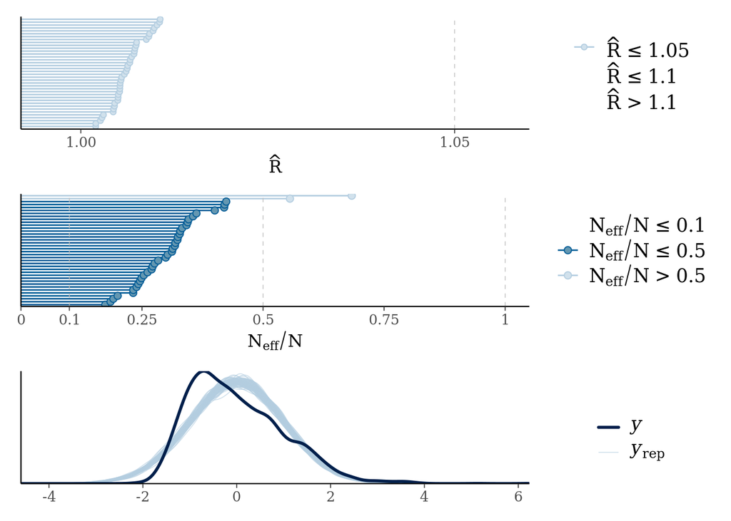

## Model 2a: Direct Effect of Past Land-Use on Large Tree (>= 5 cm DBH) Density

[figure not shown]

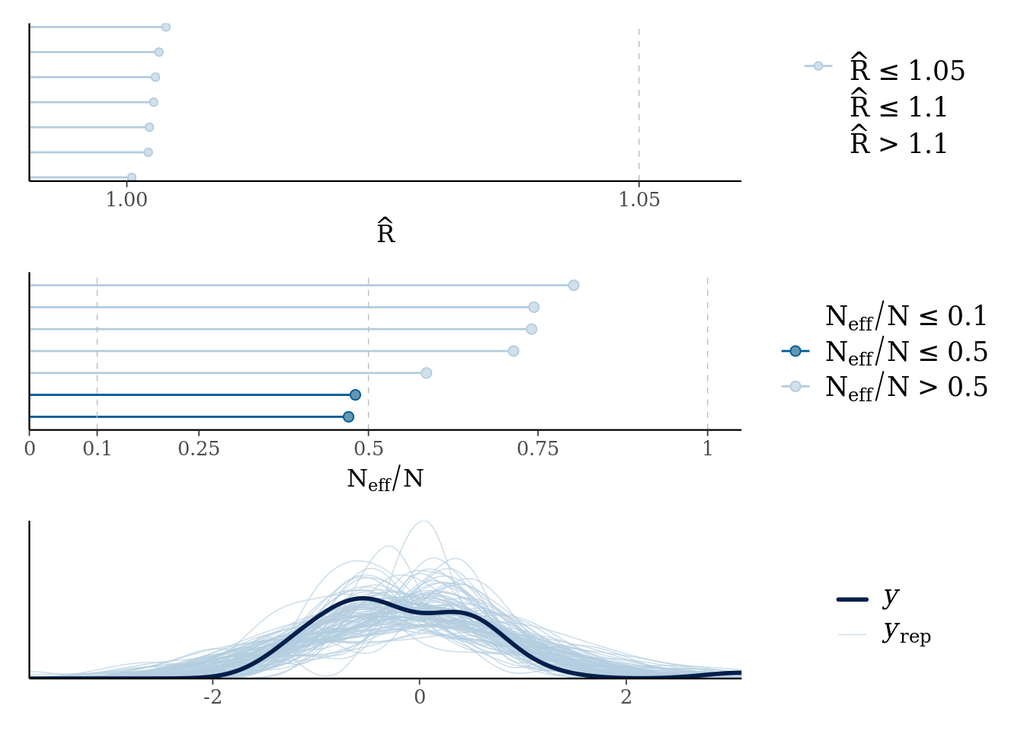

## Model 2b: Direct Effect of Past Land-Use on Small Tree (< 5 cm DBH) Density

[figure not shown]

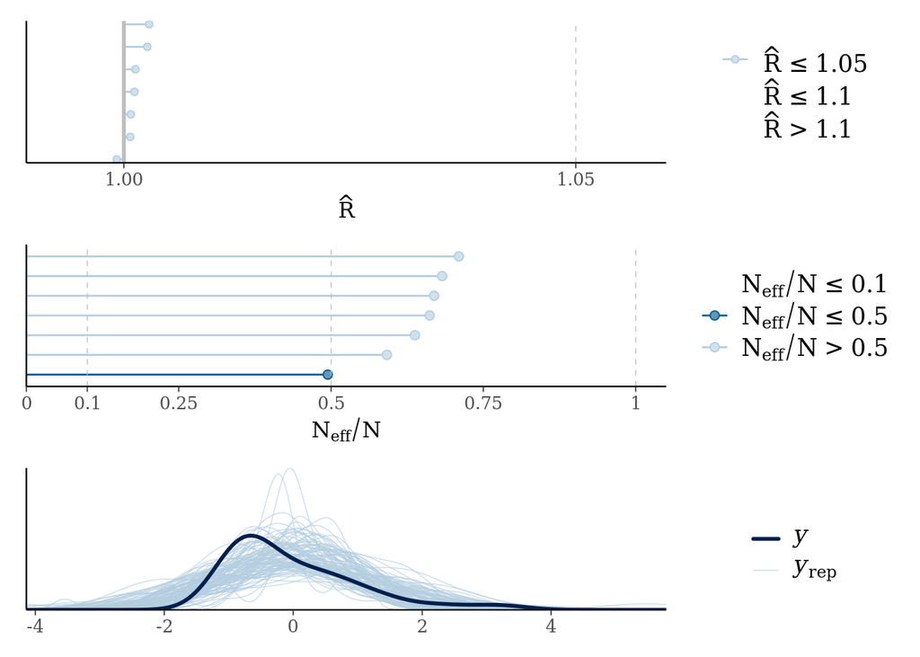

[figure not shown]

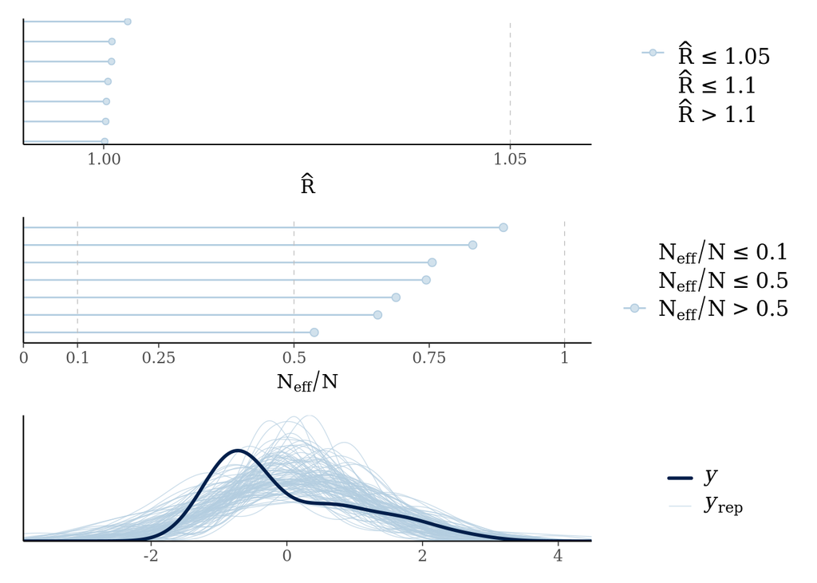

[figure not shown]

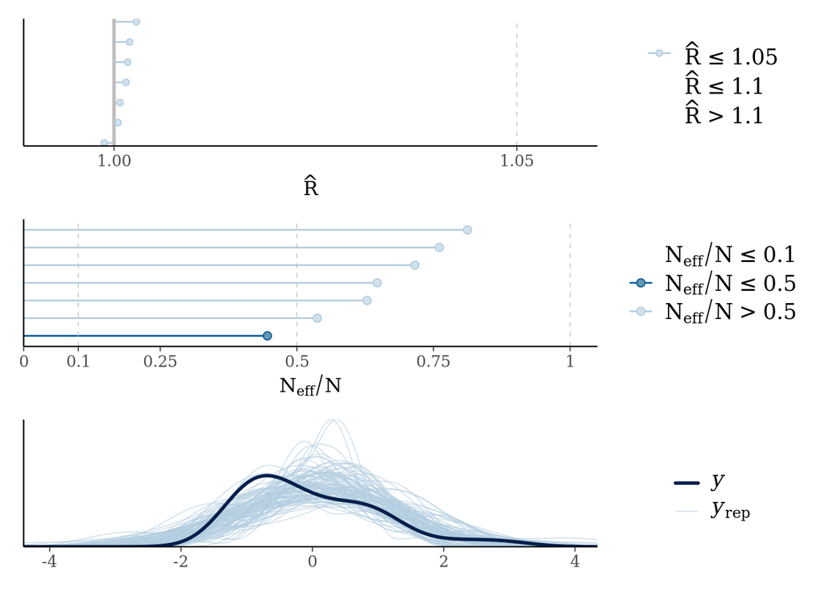

## Model 4: Direct Effect of Past Land-Use on Large Tree (>= 5 cm DBH) Species Richness

[figure not shown]

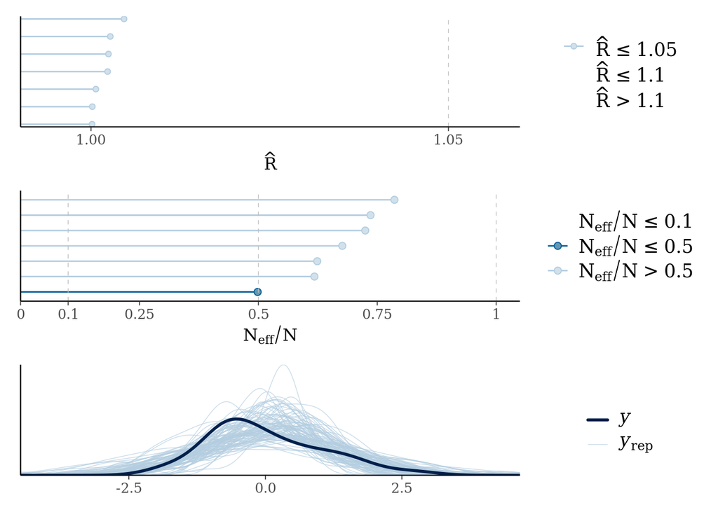

## Model 5: Direct Effect of Forest Composition on Temperature

[figure not shown]

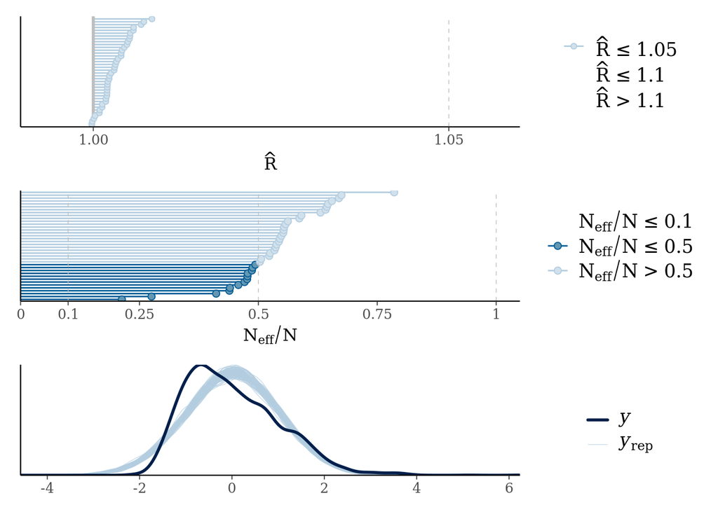